# Abalone Age Investigation

# 1 Abstract

This investigation is a regression supervised learning study of the relationship between the number of abalones rings against their physical measurements.

# 2 Introduction

Abalones have been classified as an endangered species due to overfishing which leads to regulations that prohibit fishing for abalones smaller than a certain threshold of measurements. We would like to investigate whether there is a significant linear correlation between the number of rings and size measurements of abalones.

# 3 Data set

Our dataset consist of 4177 observations and 8 attributes. It is retrieved from https://archive.ics.uci.edu/ml/datasets/abalone.

```r
# Names found in `abalone.names` information file.
cols = c("sex",
             "length",
             "diam",
             "height",
             "weight_whole",
             "weight_shucked",
             "weight_viscera",
             "weight_shell",
             "rings")

# Read the data from `abalone.data` file.
data_url = "https://archive.ics.uci.edu/ml/machine-learning-databases/abalone/abalone.data"
raw_data = readr::read_csv(data_url, cols)
raw_data
```

```
## # A tibble: 4,177 x 9
##    sex   length  diam height weight_whole weight_shucked weight_viscera
##    <chr>  <dbl> <dbl>  <dbl>        <dbl>          <dbl>          <dbl>
##  1 M      0.455 0.365  0.095        0.514         0.224          0.101
##  2 M      0.35  0.265  0.09         0.226         0.0995         0.0485
##  3 F      0.53  0.42   0.135        0.677         0.256          0.142
##  4 M      0.44  0.365  0.125        0.516         0.216          0.114
##  5 I      0.33  0.255  0.08         0.205         0.0895         0.0395
##  6 I      0.425 0.3    0.095        0.352         0.141          0.0775
##  7 F      0.53  0.415  0.15         0.778         0.237          0.142
##  8 F      0.545 0.425  0.125        0.768         0.294          0.150
##  9 M      0.475 0.37   0.125        0.509         0.216          0.112
## 10 F      0.55  0.44   0.15         0.894         0.314          0.151
## # … with 4,167 more rows, and 2 more variables: weight_shell <dbl>, rings <dbl>
```

```r
abalones = raw_data %>% mutate(sex = factor(sex, c("M", "F", "I")))
# abalones = raw_data %>%
#   mutate(
#     sex = case_when(
#     sex == "F" ~ 2,
#     sex == "M" ~ 1,
#     sex == "I" ~ 0
#   ))
```

# 4 Analysis

## 4.1 Variable selection

First we looks at plots of rings against every other variables in the dataset and see if there are any which we can fit a line through.

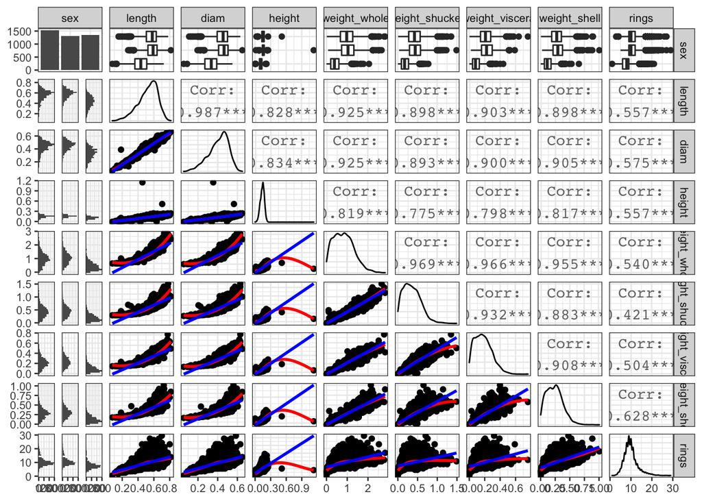

```r
# install.packages("GGally")
library(GGally)
my_fn <- function(data, mapping, ...){
p <- ggplot(data = abalones, mapping = mapping) +
    geom_point() +
    geom_smooth(method=loess, fill="red", color="red", se = FALSE) +
    geom_smooth(method=lm, fill="blue", color="blue", se = FALSE)
p
}
GGally::ggpairs(abalones, columns = 1:9, lower = list(continuous = my_fn)) + theme_bw(base_size = 10)
```

We only focus on bottom last row and right most column since they show plots of rings against every other variables and their correlations respectively. We plot two lines on every plots, one is a straight line and the other is a loose line. It seems that we might be able to fit a linear line through rings against length and diam as the loose line and straight line are relatively the same. If the two dots in height are not outliers and if we consider them valid then we won’t be able to use height, since its loose plot doesn’t show an approximately linear relationship. It might not be necessary to include other weight variables if we use weight_whole. Weight variables might need transformations.

## 4.2 Investigating Significance of Gender

Since we have a categorical variable, we will first check to see whether there is a significant difference between genders.

```r
library(dplyr)
group_by(abalones, sex) %>%
  summarise(
    count = n(),
    mean = mean(rings),
    sd = sd(rings)
  )
```

```
## # A tibble: 3 x 4
##   sex   count  mean    sd
##   <fct> <int> <dbl> <dbl>
## 1 M      1528 10.7   3.03
## 2 F      1307 11.1   3.10
## 3 I      1342  7.89  2.51
```

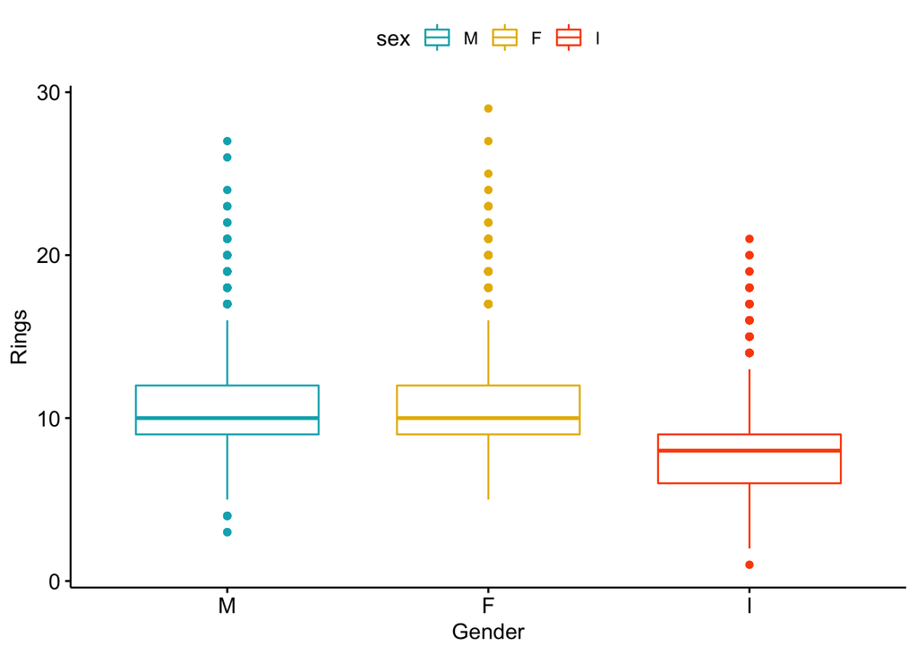

```r
library("ggpubr")
ggboxplot(abalones, x = "sex", y = "rings",
          color = "sex", palette = c("#00AFBB", "#E7B800", "#FC4E07"),
          order = c("M", "F", "I"),
          ylab = "Rings", xlab = "Gender")
```

```r
# Compute the analysis of variance
res.aov <- aov(rings ~ sex, data = abalones)
# Summary of the analysis
summary(res.aov)
```

```
##               Df Sum Sq Mean Sq F value Pr(>F)
## sex            2   8381    4191   499.3 <2e-16 ***
## Residuals   4174  35030       8
## ---
## Signif. codes:  0 '***' 0.001 '**' 0.01 '*' 0.05 '.' 0.1 ' ' 1
```

As the p-value is less than 0.05, we conclude that there are significant differences between genders.

```r
TukeyHSD(res.aov)
```

```
##   Tukey multiple comparisons of means
##     95% family-wise confidence level
##
## Fit: aov(formula = rings ~ sex, data = abalones)
##
## $sex
##           diff        lwr        upr     p adj
## F-M  0.4238064  0.1679034  0.6797094 0.0003087
## I-M -2.8150354 -3.0691334 -2.5609373 0.0000000
## I-F -3.2388418 -3.5027939 -2.9748896 0.0000000
```

```r
lm0 = lm(rings ~ ., abalones)
summary(lm0)$coefficients %>% round(4)
```

```
##                Estimate Std. Error  t value Pr(>|t|)
## (Intercept)      3.9524     0.2848  13.8758   0.0000
## sexF            -0.0577     0.0833  -0.6925   0.4887
## sexI            -0.8826     0.0957  -9.2192   0.0000
## length          -0.4583     1.8091  -0.2533   0.8000
## diam            11.0751     2.2273   4.9725   0.0000
## height          10.7615     1.5362   7.0053   0.0000
## weight_whole     8.9754     0.7254  12.3730   0.0000
## weight_shucked -19.7869     0.8174 -24.2086   0.0000
## weight_viscera -10.5818     1.2937  -8.1792   0.0000
## weight_shell     8.7418     1.1247   7.7723   0.0000
```

```r
abalones = abalones %>%
  mutate(
    sex = case_when(
    sex == "F" ~ "A",
    sex == "M" ~ "A",
    sex == "I" ~ "I"
  ))

lm0 = lm(rings ~ ., abalones)
summary(lm0)$coefficients %>% round(4)
```

```
##                Estimate Std. Error  t value Pr(>|t|)
## (Intercept)      3.9396     0.2842  13.8609   0.0000
## sexI            -0.8592     0.0896  -9.5916   0.0000
## length          -0.4488     1.8090  -0.2481   0.8041
## diam            11.0332     2.2263   4.9558   0.0000
## height          10.7372     1.5357   6.9917   0.0000
## weight_whole     8.9723     0.7253  12.3697   0.0000
## weight_shucked -19.7536     0.8159 -24.2113   0.0000
## weight_viscera -10.6179     1.2926  -8.2143   0.0000
## weight_shell     8.7409     1.1247   7.7720   0.0000
```

## 4.3 Transforming weight

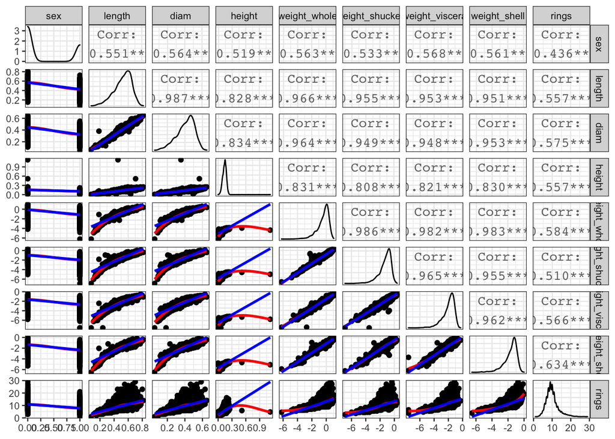

```r
abalones_lweight = abalones %>% mutate(weight_whole = log(weight_whole),
                                weight_shucked = log(weight_shucked),
                               weight_viscera = log(weight_viscera),
                               weight_shell = log(weight_shell))
abalones_lweight = abalones_lweight %>%
  mutate(
    sex = case_when(
    sex == "A" ~ 0,
    sex == "I" ~ 1
  ))
my_fn <- function(data, mapping, ...){
p <- ggplot(data = abalones_lweight, mapping = mapping) +
    geom_point() +
    geom_smooth(method=loess, fill="red", color="red", se = FALSE) +
    geom_smooth(method=lm, fill="blue", color="blue", se = FALSE)
p
}
GGally::ggpairs(abalones_lweight, columns = 1:9, lower = list(continuous = my_fn)) + theme_bw(base_size = 10)
```

```r
# sex_omitted = subset(abalones, select = -c(sex) )
# contrasts(abalones_lweight$sex)
```

```r
cor_mat = cor(abalones_lweight)
melted_cor_mat = cor_mat %>%
  data.frame() %>%
  rownames_to_column(var = "var1") %>%
  gather(key = "var2", value = "cor", -var1)
```

```r
qtlcharts::iplotCorr(abalones_lweight)
```

```
## Set screen size to height=700 x width=1000
```

[interactive chart not shown]

# 5 DROP LENGTH AND DIAM

```r
lm0 = lm(rings ~ ., abalones_lweight)
summary(lm0)$coefficients %>% round(4)
```

```
##                Estimate Std. Error  t value Pr(>|t|)
## (Intercept)      7.0192     0.9883   7.1022    0e+00
## sex             -0.5551     0.0902  -6.1536    0e+00
## length          -7.8758     1.8944  -4.1574    0e+00
## diam             7.5758     2.2327   3.3932    7e-04
## height           8.6258     1.5126   5.7024    0e+00
## weight_whole     7.2033     0.5532  13.0216    0e+00
## weight_shucked  -7.0140     0.2806 -24.9925    0e+00
## weight_viscera  -1.4009     0.2165  -6.4716    0e+00
## weight_shell     3.4219     0.2651  12.9084    0e+00
```

```r
lm0 = lm(rings ~ . - length - diam, abalones_lweight)
summary(lm0)$coefficients %>% round(4)
```

```
##                Estimate Std. Error  t value Pr(>|t|)
## (Intercept)      5.7701     0.6900   8.3626        0
## sex             -0.5812     0.0899  -6.4668        0
## height           8.5982     1.4838   5.7949        0
## weight_whole     7.0835     0.5489  12.9047        0
## weight_shucked  -7.1074     0.2793 -25.4480        0
## weight_viscera  -1.4796     0.2157  -6.8584        0
## weight_shell     3.4841     0.2631  13.2448        0
```

## 5.1 AIC

```r
step_back_aic = step(lm0, direction = "backward", trace = F)
summary(step_back_aic)
```

```
##
## Call:
## lm(formula = rings ~ (sex + length + diam + height + weight_whole +
##     weight_shucked + weight_viscera + weight_shell) - length -
##     diam, data = abalones_lweight)
##
## Residuals:
##     Min      1Q  Median      3Q     Max
## -9.4407 -1.3647 -0.3403  0.8663 16.3258
##
## Coefficients:
##                Estimate Std. Error t value Pr(>|t|)
## (Intercept)     5.77012    0.68999   8.363  < 2e-16 ***
## sex            -0.58118    0.08987  -6.467 1.12e-10 ***
## height          8.59823    1.48376   5.795 7.34e-09 ***
## weight_whole    7.08349    0.54891  12.905  < 2e-16 ***
## weight_shucked -7.10736    0.27929 -25.448  < 2e-16 ***
## weight_viscera -1.47956    0.21573  -6.858 7.99e-12 ***
## weight_shell    3.48414    0.26306  13.245  < 2e-16 ***
## ---
## Signif. codes:  0 '***' 0.001 '**' 0.01 '*' 0.05 '.' 0.1 ' ' 1
##
## Residual standard error: 2.192 on 4170 degrees of freedom
## Multiple R-squared:  0.5383, Adjusted R-squared:  0.5377
## F-statistic: 810.4 on 6 and 4170 DF,  p-value: < 2.2e-16
```

```r
step_back_aic %>%
  broom::glance() %>%
  round(2) %>% t()
```

```
##                   [,1]
## r.squared         0.54
## adj.r.squared     0.54
## sigma             2.19
## statistic       810.39
## p.value           0.00
## df                6.00
## logLik        -9202.13
## AIC           18420.25
## BIC           18470.95
## deviance      20041.59
## df.residual    4170.00
## nobs           4177.00
```

```r
drop1(step_back_aic, test = "F")
```

```
## Single term deletions
##
## Model:
## rings ~ (sex + length + diam + height + weight_whole + weight_shucked +
##     weight_viscera + weight_shell) - length - diam
##                Df Sum of Sq   RSS    AIC F value    Pr(>F)
## <none>                      20042 6564.4
## sex             1    200.99 20243 6604.1  41.820 1.116e-10 ***
## height          1    161.39 20203 6595.9  33.581 7.341e-09 ***
## weight_whole    1    800.38 20842 6726.0 166.532 < 2.2e-16 ***
## weight_shucked  1   3112.47 23154 7165.4 647.602 < 2.2e-16 ***
## weight_viscera  1    226.07 20268 6609.3  47.037 7.990e-12 ***
## weight_shell    1    843.12 20885 6734.6 175.425 < 2.2e-16 ***
## ---
## Signif. codes:  0 '***' 0.001 '**' 0.01 '*' 0.05 '.' 0.1 ' ' 1
```

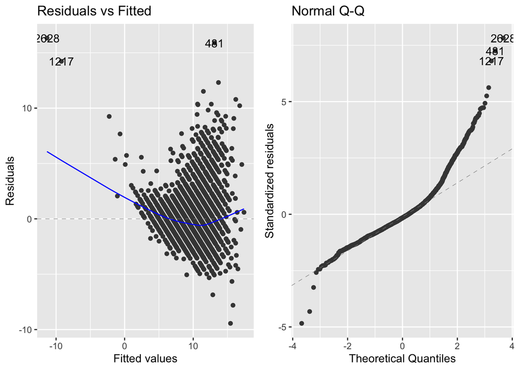

```r
library(ggfortify)
autoplot(lm0, which = 1:2)
```

# 6 DROP SOME WEIGHT

```r
lm0 = lm(rings ~ ., abalones_lweight)
summary(lm0)$coefficients %>% round(4)
```

```
##                Estimate Std. Error  t value Pr(>|t|)
## (Intercept)      7.0192     0.9883   7.1022    0e+00
## sex             -0.5551     0.0902  -6.1536    0e+00
## length          -7.8758     1.8944  -4.1574    0e+00
## diam             7.5758     2.2327   3.3932    7e-04
## height           8.6258     1.5126   5.7024    0e+00
## weight_whole     7.2033     0.5532  13.0216    0e+00
## weight_shucked  -7.0140     0.2806 -24.9925    0e+00
## weight_viscera  -1.4009     0.2165  -6.4716    0e+00
## weight_shell     3.4219     0.2651  12.9084    0e+00
```

```r
lm0 = lm(rings ~ . - weight_shell - weight_shucked - weight_viscera, abalones_lweight)
summary(lm0)$coefficients %>% round(4)
```

```
##              Estimate Std. Error t value Pr(>|t|)
## (Intercept)   10.8815     0.7688 14.1542        0
## sex           -0.9051     0.1029 -8.7931        0
## length       -18.1056     2.1683 -8.3501        0
## diam          18.1215     2.5572  7.0864        0
## height        15.8349     1.7379  9.1113        0
## weight_whole   1.7497     0.1918  9.1210        0
```

## 6.1 AIC

```r
step_back_aic = step(lm0, direction = "backward", trace = F)
summary(step_back_aic)
```

```
##
## Call:
## lm(formula = rings ~ (sex + length + diam + height + weight_whole +
##     weight_shucked + weight_viscera + weight_shell) - weight_shell -
##     weight_shucked - weight_viscera, data = abalones_lweight)
##
## Residuals:
##      Min       1Q   Median       3Q      Max
## -18.0587  -1.6024  -0.5149   0.9073  16.2262
##
## Coefficients:
##              Estimate Std. Error t value Pr(>|t|)
## (Intercept)   10.8815     0.7688  14.154  < 2e-16 ***
## sex           -0.9051     0.1029  -8.793  < 2e-16 ***
## length       -18.1056     2.1683  -8.350  < 2e-16 ***
## diam          18.1215     2.5572   7.086 1.61e-12 ***
## height        15.8349     1.7379   9.111  < 2e-16 ***
## weight_whole   1.7497     0.1918   9.121  < 2e-16 ***
## ---
## Signif. codes:  0 '***' 0.001 '**' 0.01 '*' 0.05 '.' 0.1 ' ' 1
##
## Residual standard error: 2.537 on 4171 degrees of freedom
## Multiple R-squared:  0.3818, Adjusted R-squared:  0.381
## F-statistic: 515.1 on 5 and 4171 DF,  p-value: < 2.2e-16
```

```r
step_back_aic %>%
  broom::glance() %>%
  round(2) %>% t()
```

```
##                   [,1]
## r.squared         0.38
## adj.r.squared     0.38
## sigma             2.54
## statistic       515.13
## p.value           0.00
## df                5.00
## logLik        -9811.98
## AIC           19637.95
## BIC           19682.32
## deviance      26837.87
## df.residual    4171.00
## nobs           4177.00
```

```r
drop1(step_back_aic, test = "F")
```

```
## Single term deletions
##
## Model:
## rings ~ (sex + length + diam + height + weight_whole + weight_shucked +
##     weight_viscera + weight_shell) - weight_shell - weight_shucked -
##     weight_viscera
##              Df Sum of Sq   RSS    AIC F value    Pr(>F)
## <none>                    26838 7782.1
## sex           1    497.50 27335 7856.9  77.318 < 2.2e-16 ***
## length        1    448.63 27286 7849.4  69.724 < 2.2e-16 ***
## diam          1    323.12 27161 7830.1  50.218 1.608e-12 ***
## height        1    534.16 27372 7862.5  83.016 < 2.2e-16 ***
## weight_whole  1    535.30 27373 7862.6  83.193 < 2.2e-16 ***
## ---
## Signif. codes:  0 '***' 0.001 '**' 0.01 '*' 0.05 '.' 0.1 ' ' 1
```

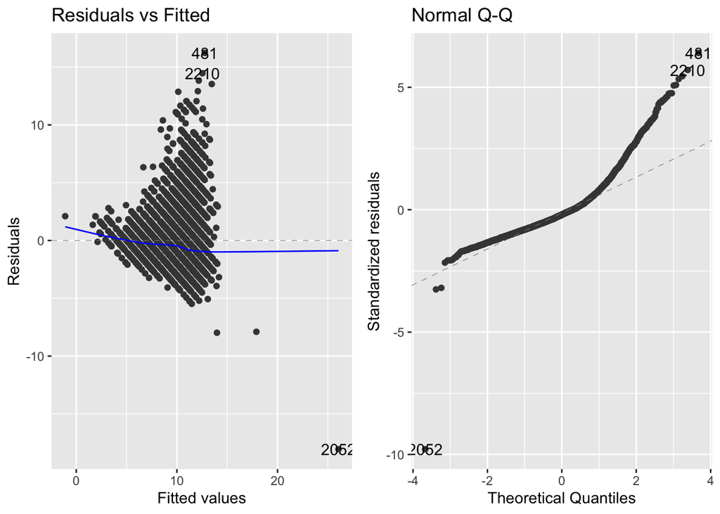

```r
autoplot(lm0, which = 1:2)
```

# 7 References

Dua, D. and Graff, C. (2019). UCI Machine Learning Repository [http://archive.ics.uci.edu/ml]. Irvine, CA: University of California, School of Information and Computer Science.